# FAQ - Generic aspects

8.1.0  
FAQ - Generic aspects

# FAQ - Generic aspects

X-CUBE-AI Expansion Package

r4.1

AI PLATFORM r8.1.0 (Embedded Inference Client API 1.2.0)

Command Line Interface r1.7.0

# Contents

- How to know the version of the deep-learning framework components which are used?
- Channel first support for ONNX model
- How is used the CMSIS-NN library?
- What is the EABI used for the *network_runtime* libraries?
- Is it possible to use the AI stack in a C++ environment?
- X-CUBE-AI Python API availability?
- Requested size of the input buffer is not aligned with the shape and data-type of the tensor?
- Stateful LSTM/GRU support?
- How is used the ONNX optimizer?
- How is used the TFLite interpreter?
- How to import a TensorFlow model (floating-point model)?
- TensorFlow Keras (tf.keras) vs Keras.io
- It is possible to update a model on the firmware w/o having to do a full firmware update?
- Keras Model or Sequential layer support?
- Is it possible to split the weights buffer?
- Is it possible to place the “activations” buffer in different memory segments?
- How to compress the non-dense/fully-connected layers?
- Is it possible to apply a compression factor different of x8, x4?
- How to specify or to indicate a compression factor by layer?
- Why a small negative ratio is reported for the weights size with a model w/o compression?
- Is it possible to dump/capture the intermediate values during the execution of the inference?
- References
- FAQ - Validation aspects
- FAQ - Quantization and post-training quantization process

# How to know the version of the deep-learning framework components which are used?

X-CUBE-AI Expansion Package is a complete self-contained application package. No external tools is requested to use the package. To know the version of the main components which are embedded, the following command can be used:

```powershell
$ stm32ai --tools_version
Neural Network Tools for STM32 family v1.7.0 (stm.ai v8.1.0)
- Python version   : 3.9.12
- Numpy version    : 1.23.0
- TF version       : 2.12.0
- TF Keras version : 2.12.0
- ONNX version     : 1.10.2
- ONNX RT version  : 1.15.0
- QKeras version   : 0.9.0
- LARQ version     : 0.12.0
```

**Warning** — User should be aware that the respective Python DL modules are used to run the original model and also to import/parse the model. To know the supported layers/operators, please refer to the description in the [TFLITE], [KERAS] and [ONNX].

# Channel first support for ONNX model

Data format of the generated C-model are always channel last (or NHWC data format). To conserve the original data arrangement, by default the transpose operators will be added if:

- model is channel first
- the number of input channels is greater than 1

This default behavior can be disabled with the option: `--no-onnx-io-transpose`

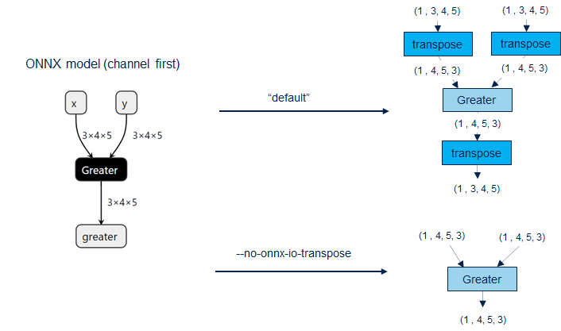

**Tip** — For the validation of the ONNX model, the data should be correctly presented by the user to build the representative data set according the generated and expected input shape.

# How is used the CMSIS-NN library?

The network runtime library is partially based on the CMSIS library. CMSIS is a vendor-independent hardware abstraction layer for micro-controllers that are based on Arm® Cortex® processors (https://arm-software.github.io/CMSIS_5/General/html/index.html). The CMSIS-NN sub-component and a minor part of the CMSIS-DSP sub-component are embedded in the *network_runtime.a* library to be sure that the requested files are compiled with the optimal options.

| component | version |
| --- | --- |
| CMSIS package | r5.9.0 |
| CMSIS-Core(M) | V5.6.0 |
| CMSIS-DSP | V1.10.0 |
| CMSIS-NN | V3.1.0 |

A part of the forward kernel functions are *directly* mapped on the CMSIS-NN (legacy support of the Qmn format) when available but the major part, are the optimized implementations (integer and float format) only based on the CMSIS-type definitions for portability across the STM32 families.

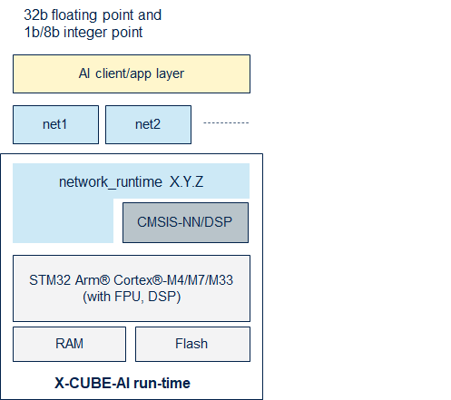

# What is the EABI used for the *network_runtime* libraries?

For performance motivations, the provided libraries (`network_runtime.a`) are compiled with the *hard* floating-point ABI option allowing generation of floating-point instructions and using FPU-specific calling conventions. This implies that the final end-user project should be also compiled and linked with this option.

**Warning** — Abnormal situation is normally detected at link time, but there is a specific case where the firmware is generated w/o errors but at run-time the results are *UNPREDICTABLE*. For example for a GCC-base environment, `-mfloat-abi=soft or softfp` can be set by default for the whole project to use an other EABI-soft-base binary library. There is currently no link issue because the library has been generated with another EABI compliant tool-chain (IAR for ARM tool-chain).

> If specific binary library version is requested see with your local ST support.

# Is it possible to use the AI stack in a C++ environment?

**Yes** - The generated `'network.c'` and `'network_data.c'` files should be compiled with the C compiler. `network_runtime` static libraries are fully compiled with a C-compiler. For the C++ application code, the AI header files should be included as follow:

```cpp
#include <iostream>
using namespace std;

extern "C" {
#include "network.h"
#include "network_data.h"
}
```

# X-CUBE-AI Python API availability?

X-CUBE-AI is only available through an UI interface (fully integrated in STM32CubeMX) and through a command line interface. Only a specific Python module (`ai_runner`) is provided to be able to run locally a generated c-model for advanced validation flow purpose (see “Python-based environment” section in [C-RUN]).

# Requested size of the input buffer is not aligned with the shape and data-type of the tensor?

Normaly the size of the buffer (`'AI_<NAME>_IN/OUT_SIZE_BYTES'`) to handle the data of the input tensor is aligned with the shape and the data-type. With a batch dim of 1, the requested size is:

```python
size_in_byte = prod(shape[1:]) * sizeof(data item)
```

Nevertheless, in some case, extra bytes can be requested to be aligned with the read accesses (4-bytes aligned) performed by the c-kernels. If these read accesses refer a non-memory mapped region, HW exception can be generated. To avoid this situation, the code generator adds if necessary the extra bytes (max. 3 bytes) to the requested “normal” size according to the parameter and the type of first operator.

**Note** — These extra bytes should be always placed at the end of the buffer and will be accessed in read mode only. Base address of the allocated buffer must be always 4-bytes aligned.

Following C-defines are generated for a quantized model with input RGB image (128x128x3).

```python
/* @file: network.h */

#define AI_NETWORK_IN_1_HEIGHT      (128)
#define AI_NETWORK_IN_1_WIDTH       (128)
#define AI_NETWORK_IN_1_CHANNEL     (3)
#define AI_NETWORK_IN_1_SIZE        (128 * 128 * 3)
#define AI_NETWORK_IN_1_SIZE_BYTES  (49153)    /* = 128x128x3 + 1 */
```

# Stateful LSTM/GRU support?

For the ONNX LSTM and TFlite UNIDIRECTIONAL_SEQUENCE_LSTM operators, only stateless mode is supported. There is only a limited support for the Keras LSTM/GRU layer in stateful mode.

# How is used the ONNX optimizer?

Example of error message:

```powershell
(op_type:LeakyRelu, name:LeakyRelu_26): Inferred shape and existing shape differ in rank: (3) vs (2)
INTERNAL ERROR: list index out of range
```

# How is used the TFLite interpreter?

For the built-in validation flow, the TFLite interpreter is used to generate the predictions which will be compared to the outputs of the generated c-model. As the X-CUBE-AI c-runtime inference engine is stateless for the supported operators, between two samples, `reset_all_variables()` method is called.

# How to import a TensorFlow model (floating-point model)?

- [https://www.tensorflow.org/lite/models/convert](https://www.tensorflow.org/lite/convert)
- https://www.tensorflow.org/api_docs/python/tf/lite/TFLiteConverter

Tensorflow model can be not directly imported in X-CUBE-AI. There is two ways to export a TensorFlow model that could be imported:

- save the TensorFlow model as a Keras model file. In this case, the generated Keras file (h5 file) should be directly imported. This approach is only possible for the model using the high level Keras API.
- use the `TFLiteConverter` to create a TFlite file (tflite file). For the model using the high level Keras API, this approach can be also used to apply the built-in optimizations (folding of the BN,..) but also where specific Keras custom layers are used and deployable as the TFLite operators.

```python
import tensorflow as tf

converter = tf.lite.TFLiteConverter.from_saved_model(saved_model_dir)
# converter = tf.lite.TFLiteConverter.from_keras_model(model)
tflite_model = converter.convert()
open("converted_model.tflite", "wb").write(tflite_model)
```

# TensorFlow Keras (tf.keras) vs Keras.io

```powershell
...
INTERNAL ERROR: The Conv2D op currently only supports the NHWC tensor format
                on the CPU. The op was given the format: NCHW [Op:Conv2D]
...
```

If the user wants to validate the generated c-model, he must provide a test data set. The `'--no-exec-model'` option can be used to avoid to execute the imported model.

```powershell
> stm32ai validate -m <keras_model_with_NCHW>.h5 -vi test.npz --no-exec-model
...

Evaluation report (summary)
------------------------------------------------------------------------------------------------------
Mode              acc      rmse      mae       l2r       tensor
------------------------------------------------------------------------------------------------------
x86 C-model #1    100.00%  0.000000  0.000000  0.000000  activation_6 [ai_float, (1, 1, 2), m_id=20]
```

# It is possible to update a model on the firmware w/o having to do a full firmware update?

**Yes** - The `'--binary'` and `'--relocatable'` options of the `'generate'` command allow to implement a simple or complete mechanism to be able to upgrade a whole generated c-model w/o having to do a full firmware update (refer to [CLI] or [RELOC], *“Relocatable binary model support*” article).

# Keras Model or Sequential layer support?

Nested topologies are not supported. This can appear when the Keras functional API is used to build the network and a `'Model'` object is called as a layer.

A possible work-around is to convert the Keras model to a TensorFlow lite model, if all operators are supported.

```python
converter = tf.lite.TFLiteConverter.from_keras_model_file(<keras_model_path>)
model = converter.convert()
```

# Is it possible to split the weights buffer?

**Yes,** by weights/bias tensors, see the `'--split-weights'` option (refer to [CLI]).

# Is it possible to place the “activations” buffer in different memory segments?

**Yes**, with the X-CUBE-AI 7.1, the user has the possibility to generate a c-model with multiple activations buffers (or heap).

# How to compress the non-dense/fully-connected layers?

Only the 32b floating-point dense/fully-connected layer can be compressed.

# Is it possible to apply a compression factor different of x8, x4?

**No.** The underlying weight-sharing algorithm (K-means clustering) is based on a dictionary with 16 (x8) or 256 (x4) entries. At the end, the global gain depends of the parameter number versus dictionary size. Note that for a given layer, bias parameters are not necessarily compressed. Compression is applied by tensor.

# How to specify or to indicate a compression factor by layer?

By default, the compression process tries to apply globally the same compression level for all eligible operators. A JSON file can be defined, to indicate what is the compression level which must be applied for a given layer. The layer is specified by its original name (refer to *“Specify a compression level by operator”* section [CLI])

# Why a small negative ratio is reported for the weights size with a model w/o compression?

X-CUBE-AI optimizer implements different merging engine, allowing for example to fold a batch-normalization layer in the previous layer. In this case the reported value take account of these optimizations, the parameters of the batch-normalization layer are removed in the generated C-model.

```powershell
$ stm32ai analyze -m ds_cnn.h5
...
weights (ro)       : 159,536 (155.80 KiB) (-0.64%)
...
```

# Is it possible to dump/capture the intermediate values during the execution of the inference?

**Yes**, thanks the usage of the Platform Observer API (refer to [API], *“Platform Observer API”* section) in C-environment (STM32 or X86) or in Python environment with the `ai_runner` module (refer to [C-RUN] “How to run locally a c-model” article).

# References

| ref | description |
| --- | --- |
| [DS] | X-CUBE-AI - AI expansion pack for STM32CubeMX https://www.st.com/en/embedded-software/x-cube-ai.html |
| [UM] | User manual - Getting started with X-CUBE-AI Expansion Package for Artificial Intelligence (AI) [(pdf)](https://www.st.com/resource/en/user_manual/dm00570145.pdf) |
| [CLI] | stm32ai - Command Line Interface (link) |
| [API] | Embedded inference client API (link) |
| [METRIC] | Evaluation report and metrics (link) |
| [TFL] | TensorFlow Lite toolbox (link) |
| [KERAS] | Keras toolbox (link) |
| [ONNX] | ONNX toolbox (link) |
| [ONNX-ML] | Machine Learning support (ONNX-ML operators) (link) |
| [DQNN] | Deep Quantized Neural Network support (link) |
| [FAQS] | FAQ generic, validation, quantization |
| [QUANT] | Quantization (link) |
| [QUANT_CMD] | Quantization Command (link) |
| [RELOC] | Relocatable binary network support (link) |
| [CUST] | Support of the Keras Lambda/custom layers (link) |
| [TFLM] | TensorFlow Lite for Microcontroller support (link) |
| [INST] | Setting the environment (link) |
| [OBS] | Platform Observer API (link) |
| [C-RUN] | Executing locally a generated c-model (link) |
| [BREAK] | API Breaking changes (link) |
| [CRC] | STM32 CRC IP as shared resource (link) |

Embedded Documentation - **FAQ - Generic aspects**  
X-CUBE-AI Expansion Package  
r4.1 - AI PLATFORM r8.1.0 (Embedded Inference Client API 1.2.0) - Command Line Interface r1.7.0

Information in this document is provided solely in connection with ST products. The contents of this document are subject to change without prior notice.  
© Copyright STMicroelectronics 2020. All rights reserved. www.st.com